# DAB501 Final Project

## Student Information

- Name:
  - Vikrant Siwach
  - Rituraj Borah
  - Ikram Patel
- ID:
  - 0824836
  - 0825448
  - 0822315

## Instructions

Follow the instructions on the handout provided.

## Packages and Data

```r
library(tidyverse)
library(dplyr)
library(tinytex)
options(scipen = 999)
```

```r
#importing data

#bal_cit_data <- read.csv("Baltimore_City_Employee_Salaries.csv")
bal_cit_data <- read.csv("C:/Users/hp/Downloads/Baltimore_City_Employee_Salaries.csv")

bal_cit_data_frame <-data.frame(bal_cit_data)

#Generating Sectors/categories from Agencies

defence  <- c('A99','A64','A38','A54','A11','BPD','A08','A51','A26','A57','R01','D01')

public_works <- c('A50','A90','A04','A06','A49','B70','A67','C90','A70','A41','B49','A84','A68','B68','P04')

govt <- c('A03','A29','A31','A75','A40','A09','A30','A10','A01','A91','A02','A37','A33','A52','W07','A73','A35','A28','A86')

others <- c('A85','A83','A19','A46','A39','W08','W03','SCS','A51','A44','P83','U01','A65','P65')

finance <- c('A24','A17','A32','A15','A14','A23','A18','A16','A12','A88','A53')

bal_cit_data_frame$sector <-

  as.factor(ifelse(bal_cit_data_frame$agencyID %in% defence, 'defence',

                     ifelse(bal_cit_data_frame$agencyID %in% public_works, 'public_works',

                     ifelse(bal_cit_data_frame$agencyID %in% govt, 'govt',

                     ifelse(bal_cit_data_frame$agencyID %in% others, 'others','finance')))))


#Cleaning data

bal_cit_data_frame_new<-bal_cit_data_frame[is.na(as.numeric(bal_cit_data_frame$middleInitial)),]

bal_cit_data_frame_final <- bal_cit_data_frame_new[!is.na(bal_cit_data_frame_new$hireDate),]

bal_cit_data_frame_final$hireDate<-as.Date(bal_cit_data_frame_final$hireDate)

bal_cit_data_frame_final$hire_year <- format(bal_cit_data_frame_final$hireDate,format= "%Y")

bal_cit_data_frame_final$hire_year <- as.numeric(format(bal_cit_data_frame_final$hireDate,format= "%Y"))

#Removing 'FY' from the Fiscal Year data

bal_cit_data_frame_final$fiscalYear <- as.factor(gsub("FY","",bal_cit_data_frame_final$fiscalYear))

# segregating gross pay into Salary classes

breaks <- c(0,35000,70000,105000,140000,373111)

bal_cit_data_frame_final$gross_range <- cut(bal_cit_data_frame_final$grossPay,breaks,labels=c("verylow","low","medium","High","very High"),include.lowest = TRUE)

# segregating annual pay into Salary classes

annual_break <- c(0,35000,70000,105000,140000,280000)

bal_cit_data_frame_final$annual_range <- cut(bal_cit_data_frame_final$annualSalary,annual_break,labels=c("Very Low (0-35K)","Low (35K-70K)","Medium (70K-105K)","High (105K-140K)","Very High (>140K)"),include.lowest = TRUE)

#Filtering data to include employees with Annual and Gross Salaries greater than $10,000
bal_cit_data_frame_regression <- subset(bal_cit_data_frame_final, annualSalary >= 10000 & grossPay >= 10000)
```

### Dataset Description:

The above dataset includes Baltimore City employee details like name, jobclass, department, annual salaries, gross pay etc. from fiscal year 2011 through last fiscal year. Out of those, we are planning to use below two variables to design our linear regression model, post our analysis.

- **annualSalary**: The employee’s base annual salary for the fiscal year.
- **grossPay**: The total sum of compensation the employee received during the fiscal year.

## MODELING: Gross Salary~Annual Salary

### Question 1

Explanatory variable = Annual Salary (annualSalary)

### Question 2

Response variable = Gross Salary (grossPay)

### Question 3

#### Identifying correlation coefficient

```r
cor(bal_cit_data_frame_regression$annualSalary,bal_cit_data_frame_regression$grossPay)
```

```
## [1] 0.8546223
```

#### Scatterplot of Gross Salary vs Annual Salary

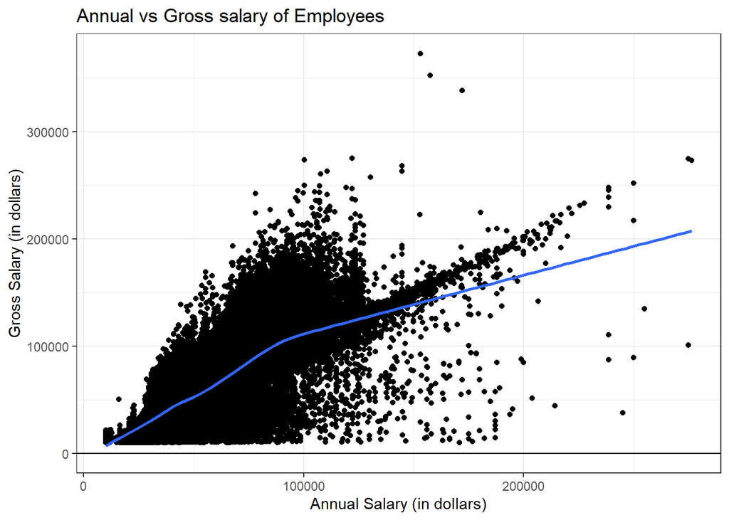

```r
ggplot(bal_cit_data_frame_regression, aes(x = annualSalary, y = grossPay)) +
  geom_point() +
  geom_smooth(se=FALSE) +
  geom_hline(yintercept = 0) + labs(title = "Annual vs Gross salary of Employees",x = "Annual Salary (in dollars)", y = "Gross Salary (in dollars)") + theme_bw()
```

In Addition to correlation coefficient, the above Scatterplot also depicts that there exists a positive relationship between Annual Salary and Gross Salary

```r
regr<- lm(formula = grossPay~annualSalary ,data=bal_cit_data_frame_regression)

summary(regr)
```

```
##
## Call:
## lm(formula = grossPay ~ annualSalary, data = bal_cit_data_frame_regression)
##
## Residuals:
##     Min      1Q  Median      3Q     Max
## -233903   -6012   -1684    4381  204253
##
## Coefficients:
##                  Estimate   Std. Error t value            Pr(>|t|)
## (Intercept)  -2026.828084   110.652498  -18.32 <0.0000000000000002 ***
## annualSalary     1.115903     0.001819  613.48 <0.0000000000000002 ***
## ---
## Signif. codes:  0 '***' 0.001 '**' 0.01 '*' 0.05 '.' 0.1 ' ' 1
##
## Residual standard error: 15880 on 138935 degrees of freedom
## Multiple R-squared:  0.7304, Adjusted R-squared:  0.7304
## F-statistic: 3.764e+05 on 1 and 138935 DF,  p-value: < 0.00000000000000022
```

From the linear model, we get the following results:

**Slope = 1.12**

**Intercept = -2027**

### Question 4

The equation for the regression line is:  
*Gross Salary = -2027 + 1.12 x (Annual Salary)*

### Question 5

For Annual Salary = 0, then

Gross Salary = -2027 (in dollars)

This concludes that for any individual with zero annual Salary will have gross salary as $ -2027.

### Question 6

The equation for the regression line is:  
*Gross Salary = -2027 + 1.12 x (Annual Salary)*

As negative gross salary is not a possible scenario for an unpaid employed individual. We state that intercept for our case doesn’t relate to any significant value. In a possible situation, a person having no annual salary would not have gross salary.

### Question 7

As observed from equation of regression line,

Slope = 1.12

A slope of 1.12 means for every dollar increase in annual salary, on average, gross salary of any individual will have an increase of $1.12.

## MODEL DIAGNOSTICS

### Question 1

Creating the data columns for predicted value of Gross Salary and their respective residuals.

```r
#using equation of linear regression model, identifying all predicted values
Gross_predict = (1.116*bal_cit_data_frame_regression$annualSalary) - 2027

#extracting residuals from our predicted values
Resid_cl_regr <- bal_cit_data_frame_regression$grossPay - Gross_predict

#Creating a dataframe column of predicted values and their respective residuals
bal_cit_data_frame_regression <- bal_cit_data_frame_regression %>%
 mutate(Gross_predict = Gross_predict,
Resid_cl_regr = Resid_cl_regr)

bal_cit_data_frame_regression %>% select(annualSalary, grossPay, Gross_predict, Resid_cl_regr)
```

|  | annualSalary | grossPay | Gross_predict | Resid_cl_regr |
| --- | --- | --- | --- | --- |
| 1 | 34115.00 | 44557.99 | 36045.340 | 8512.650 |
| 3 | 63457.00 | 29461.96 | 68791.012 | -39329.052 |
| 4 | 74299.00 | 85450.35 | 80890.684 | 4559.666 |
| 5 | 68226.00 | 102775.97 | 74113.216 | 28662.754 |
| 6 | 72033.00 | 73367.20 | 78361.828 | -4994.628 |
| 7 | 79827.00 | 81305.63 | 87059.932 | -5754.302 |
| 8 | 72007.00 | 103168.86 | 78332.812 | 24836.048 |
| 9 | 97058.00 | 143215.40 | 106289.728 | 36925.672 |
| 10 | 55117.00 | 41074.56 | 59483.572 | -18409.012 |
| 11 | 67771.00 | 69809.82 | 73605.436 | -3795.616 |

[output cut: 9990 more lines]

### Question 2

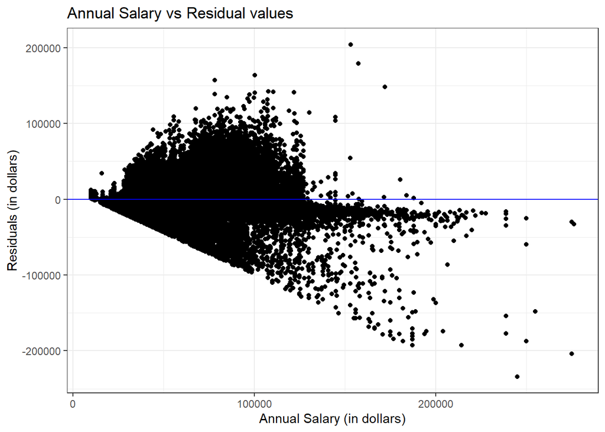

```r
ggplot(bal_cit_data_frame_regression, aes(x = annualSalary, y = Resid_cl_regr)) + geom_point()+
  geom_hline(yintercept = 0, colour = 'blue') + labs(title = "Annual Salary vs Residual values",x = "Annual Salary (in dollars)", y = "Residuals (in dollars)") + theme_bw()
```

### Question 3

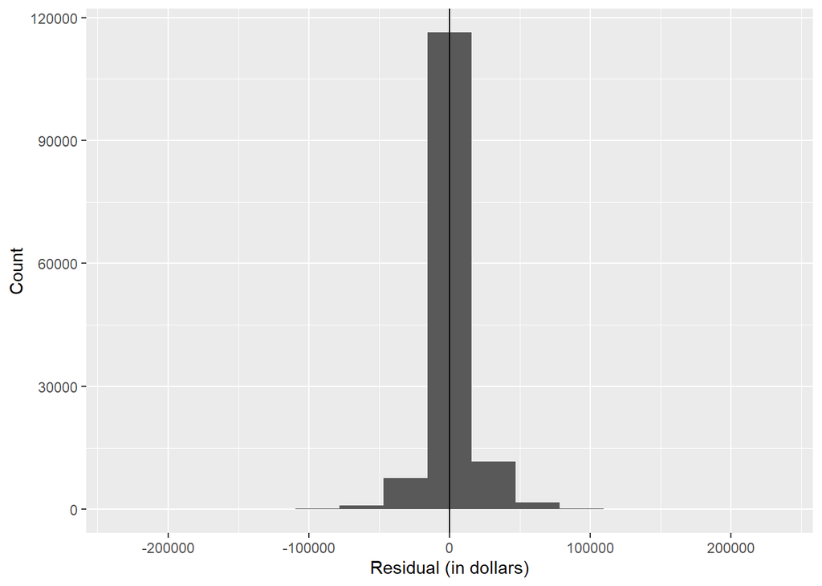

```r
#Nearly normal Residual
ggplot(bal_cit_data_frame_regression) + geom_histogram(mapping = aes(x= Resid_cl_regr),bins = 15) + geom_vline(xintercept = 0) + labs(x = "Residual (in dollars)", y = "Count")
```

Based on the histogram above, the residual distribution is a unimodal & symmetric and hence, appear to be nearly normal so **the condition of nearly normal residuals is met.**

### Question 4

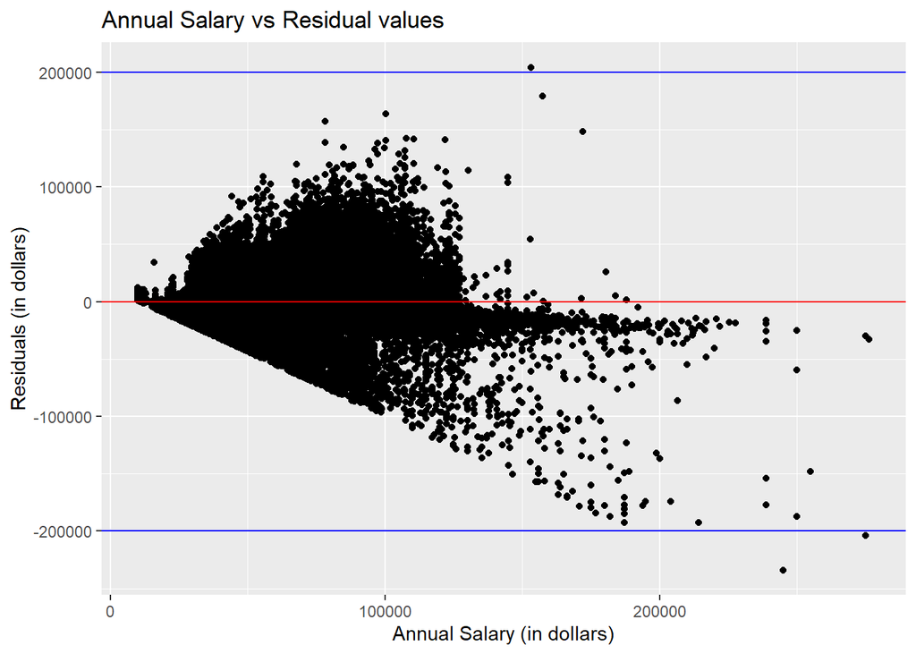

```r
#Constant variability Check
ggplot(bal_cit_data_frame_regression, aes(x = annualSalary, y = Resid_cl_regr)) + geom_point()+
  geom_hline(yintercept = 0, colour = 'red') +
  geom_hline(yintercept = 200000, colour = 'blue') +
  geom_hline(yintercept = -200000, colour = 'blue')  + labs(title = "Annual Salary vs Residual values",x = "Annual Salary (in dollars)", y = "Residuals (in dollars)")
```

Since the residuals between the two horizontal blue lines appear to be moving funneling out and moving away from 0 with an increase in annual salary and there seems to be an obvious trend that alters the variability, as annual salary increases. Hence, **the condition of constant variability has not met.**

## CONCLUSION

### Question 1

The equation for the linear regression model is:  
*Gross Salary = -2027 + 1.12 x (Annual Salary)*